# Association between communication difficulty and high impact pain in U.S. adults

BMIN503/EPID600 Final Project

Author

Amber Rhee, MHS

Use this template to complete your project throughout the course. Your Final Project presentation will be based on the contents of this document. Replace the title/name above and text below with your own, but keep the headers. Feel free to change the theme and other display settings, although this is not required. I added a new sentence

## 1 Overview

Give a brief a description of your project and its goal(s), what data you are using to complete it, and what two faculty/staff in different fields you have spoken to about your project with a brief summary of what you learned from each person. Include a link to your final project GitHub repository.

For my final project, I am using data from the 2023 NHIS’s (Sample Adult) communication core and chronic pain content to examine the association between one’s communication ability (which can, e.g., translate into ability to communicate symptoms to providers) and high impact pain (pain defined as significant enough to limit daily activities). John Farrar, MD, PhD has helped me consider potential confounders and effect modifiers that may affect the association between my variables of interest, while Adam Naj, PhD has helped me decide how I want to model the actual data in my analyis.

[Final Project Repo](https://github.com/jamberhee/BMIN503_Final_Project)

## 2 Introduction

Describe the problem addressed, its significance, and some background to motivate the problem. This should extend what is in the Section 1.

Chronic pain is a major public health concern in the U.S., with high prevalence across sociodemographic groups [1]. The incidence of chronic pain cases is reported greater than the incidence of diabetes, depression, and hypertension [2] And disparities in pain management are significant [3].

The official definition of pain acknowledges pain as a subjective experience, where an individual’s report of pain is to be respected [4]. It also notes, “inability to communicate does not negate the possibility that a human […] experiences pain” [4].

Communication requires both a patient to properly express their symptoms and a healthcare provider to listen and understand. Verbal communication is considered the “gold standard” for pain assessment [5]. A review found that a major reason for provider dismissal and downgrading of patient credibility regarding their pain was due to ineffective pain communication by the patient [5]. Additional qualitative research has found healthcare providers view pain assessment in individuals with communication difficulties to be challenging and time-consuming [6]. And yet, disparities in pain in relation to communication difficulties are not well documented or quantified.

References

1. Rikard SM, Strahan AE, Schmit KM, Guy GP Jr.. Chronic Pain Among Adults — United States, 2019–2021. MMWR Morb Mortal Wkly Rep 2023;72:379–385. DOI: http://dx.doi.org/10.15585/mmwr.mm7215a1
2. Nahin RL, Feinberg T, Kapos FP, Terman GW. Estimated Rates of Incident and Persistent Chronic Pain Among US Adults, 2019-2020. JAMA Netw Open. 2023 May 1;6(5):e2313563. doi: 10.1001/jamanetworkopen.2023.13563. PMID: 37191961; PMCID: PMC10189566.
3. Nguyen LH, Dawson JE, Brooks M, Khan JS, Telusca N. Disparities in Pain Management. Anesthesiol Clin. 2023 Jun;41(2):471-488. doi: 10.1016/j.anclin.2023.03.008. PMID: 37245951.
4. Raja SN, Carr DB, Cohen M, Finnerup NB, Flor H, Gibson S, Keefe FJ, Mogil JS, Ringkamp M, Sluka KA, Song XJ, Stevens B, Sullivan MD, Tutelman PR, Ushida T, Vader K. The revised International Association for the Study of Pain definition of pain: concepts, challenges, and compromises. Pain. 2020 Sep 1;161(9):1976-1982. doi: 10.1097/j.pain.0000000000001939. PMID: 32694387; PMCID: PMC7680716.
5. Sabater-Gárriz Á, Molina-Mula J, Montoya P, Riquelme I. Pain assessment tools in adults with communication disorders: systematic review and meta-analysis. BMC Neurol. 2024 Feb 17;24(1):66. doi: 10.1186/s12883-024-03539-w. PMID: 38368314; PMCID: PMC10873938.
6. Tosas MR. The downgrading of pain sufferers’ credibility. Philos Ethics Humanit Med. 2021 Oct 6;16(1):8. doi: 10.1186/s13010-021-00105-x. PMID: 34610826; PMCID: PMC8493671.

Explain why your problem is interdisciplinary, what fields can contribute to its understanding, and incorporate background related to what you learned from meeting with faculty/staff.

Because pain is defined by a biopsychosocial model, meaning physiological, psychological, and social factors all play an integral role, interacting with each other to create pain outcomes [7], attempting to study pain at the population level is, thus, an intricate task. I could benefit to receive inputs from general practitioners, pain specialists, psychologists, and even behavioral and social scientists to gain insights on my research question but also from epidemiologists to learn to how I can explore this question in a nationally-representative survey and what considerations I have to make in the process. Dr. John Farrar, as both a clinical epidemiologist and pain clinician, has helped me conceptualize my causal framework for this analysis, particularly when thinking about potential confounders. Dr. Adam Naj, as an epidemiologist, has helped me identify how to best model my data and think about data missingness.

References

7. Meints SM, Edwards RR. Evaluating psychosocial contributions to chronic pain outcomes. Prog Neuropsychopharmacol Biol Psychiatry. 2018 Dec 20;87(Pt B):168-182. doi: 10.1016/j.pnpbp.2018.01.017. Epub 2018 Jan 31. PMID: 29408484; PMCID: PMC6067990.

## 3 Methods

Describe the data used and general methodological approach used to address the problem described in the Section 2. Subsequently, incorporate full R code necessary to retrieve and clean data, and perform analysis. Be sure to include a description of code so that others (including your future self) can understand what you are doing and why.

I used “Sample Adult” data from the 2023 National Health Interview Survey (NHIS). Estimates from the NHIS are designed to be representative of the noninstitutionalized civilian population of the U.S.

> Install and load libraries

```r
# install.packages("tidyverse)
# install.packages("survey")
# install.packages("gtsummary")

library(tidyverse)
library(survey)
library(table1)
library(corrplot)
library(gtsummary)
```

> Load data

```r
## loaded according to recommended/provided code from NHIS
### prevents errors in reading in data file due to missingness in data
adult2023 <- read_csv("adult23.csv", guess_max = 29522)
## https://ftp.cdc.gov/pub/Health_Statistics/NCHS/Datasets/NHIS/2023/adult23csv.zip
```

Communication difficulty was determined by the question, “Using your usual language, do you have difficulty communicating, for example, understanding or being understood?” Participants could respond, “No difficulty”, “Some difficulty”, “A lot of difficulty”, or “Cannot do at all.” Due to small sample size, I collapsed the “A lot of difficulty” and “Cannot do at all” participants into a single group.

Participants were asked, “In the past three months, how often did you have pain?”, to which they could answer, “Never,” “Some days,” “Most days,” or “Every day.” Only those who reported any pain to this question were asked the follow question: “Over the past three months, how often did your pain limit your life or work?” High impact pain was defined as pain that limited life or work “Most days” or “Every day.” Participants who responded “Never” or “Some days” or reported no pain in the last three months were classified as individuals without high impact pain.

> Initial inspection of data for sample size

```r
## check unique adults in dataset
### 29522 adults--one row per participant
length(unique(adult2023$HHX))
```

```
[1] 29522
```

```r
## change missing to NA
## convert comm difficulty variable to factor
## collapse lots + completely due to small cell size
adult2023 <- adult2023 %>%
  mutate(COMDIFF_A = as.factor(case_when(adult2023$COMDIFF_A > 4 ~ NA,
                               adult2023$COMDIFF_A == 4 |
                                 adult2023$COMDIFF_A == 3 ~ "Lots or Completely",
                               adult2023$COMDIFF_A == 2 ~ "Some",
                               adult2023$COMDIFF_A == 1 ~ "None")))
adult2023$COMDIFF_A <- factor(adult2023$COMDIFF_A,
                              levels = c("None","Some","Lots or Completely"))
table(adult2023$COMDIFF_A,useNA = "always")
```

```
              None               Some Lots or Completely               <NA>
             27796               1471                248                  7
```

```r
## change missing to NA
## convert high impact pain variable to factor
adult2023$PAIWKLM3M_A <- ifelse(adult2023$PAIWKLM3M_A > 4, NA, adult2023$PAIWKLM3M_A)
adult2023$PAIWKLM3M_A <- factor(adult2023$PAIWKLM3M_A,
                                labels = c("Never","Some","Most","Every"))
table(adult2023$PAIWKLM3M_A)
```

```
Never  Some  Most Every
 9321  7412  1479  1621
```

```r
## create pain binary variable for outcome
adult2023 <- adult2023 |>
  mutate(hip_binary = ifelse(adult2023$PAIWKLM3M_A == "Never" |
                               adult2023$PAIWKLM3M_A == "Some", 0, 1))

## examine outcome for sample size
table(adult2023$hip_binary)
```

```
    0     1
16733  3100
```

```r
prop.table(table(adult2023$COMDIFF_A,adult2023$hip_binary),2)
```

```
                              0          1
  None               0.94823979 0.85290323
  Some               0.04590282 0.12161290
  Lots or Completely 0.00585739 0.02548387
```

> Examine sampling

```r
## rename variables of interest
## 7 participants missing exposure
## cannot filter out individuals because
### all of the strata need to be used in the calculation of the standard error
data <- adult2023 %>%
  as.data.frame() %>%
  rename(id = HHX,
         strata = PSTRAT,
         sweight = WTFA_A,
         psu = PPSU,
         comdiff = COMDIFF_A,
         pain = PAIFRQ3M_A,
         hip = PAIWKLM3M_A)

## if participants have no pain, no hip also
data <- data %>%
  mutate(hip = ifelse(pain == 1, 1, hip)) %>%
  mutate(hip_binary = ifelse(pain == 1, 0, hip_binary))
weighted_data_test <-svydesign(id=~psu, weights=~sweight,
                          strata=~strata, nest=TRUE,
                          data = data)

summary(weighted_data_test)
```

```
Stratified 1 - level Cluster Sampling design (with replacement)
With (662) clusters.
svydesign(id = ~psu, weights = ~sweight, strata = ~strata, nest = TRUE,
    data = data)
Probabilities:
     Min.   1st Qu.    Median      Mean   3rd Qu.      Max.
2.505e-05 9.095e-05 1.356e-04 1.632e-04 2.154e-04 5.579e-04
Stratum Sizes:
           100 101 102 103 104 105 106 107 108 109 110 111 112 113 114 115 116
obs        853 696 579 437 546 551 634 790 844 691 549 510 129 843 387 540 190
design.PSU  17  19  16  12  11  12  14  19  17  16  15   9   3  16  10  14   7
actual.PSU  17  19  16  12  11  12  14  19  17  16  15   9   3  16  10  14   7
           117 118 119 120 121 122 123 124 125 126 127 128 129 130 131 132 133
obs        635 591 797 494 627 557 276 535 358 601 466 303 782 526 583 538 589
design.PSU  15  14  14  12  11  16   7  14  10  15  10   6  13  12  14  12  14
```

[output cut: 172 more lines]

```r
svytable(~comdiff+hip, weighted_data_test)
```

```
                    hip
comdiff                        1           2           3           4
  None               156926703.1  57871790.3  10416313.8  10043035.2
  Some                 5407931.5   3945219.6   1038581.1   1907211.5
  Lots or Completely   1241602.8    496254.8    170162.4    397803.5
```

```r
svytable(~comdiff+hip_binary, weighted_data_test)
```

```
                    hip_binary
comdiff                      0         1
  None               214798493  20459349
  Some                 9353151   2945793
  Lots or Completely   1737858    567966
```

Confounders and effect modifiers were identified a priori from the literature and discussed with Dr. Farrar. My hypothetical causal framework is depicted in a directed acyclic graph (DAG) below. Of my proposed confounders, 2 were not captured in the data–autism and stress. They cannot, thus, be controlled for the in the analysis. I used “use of a hearing aid” as a proxy for hearing loss. All conditions (stroke, dementia, fatigue, anxiety) are ever-diagnoses.

> Identify confounders

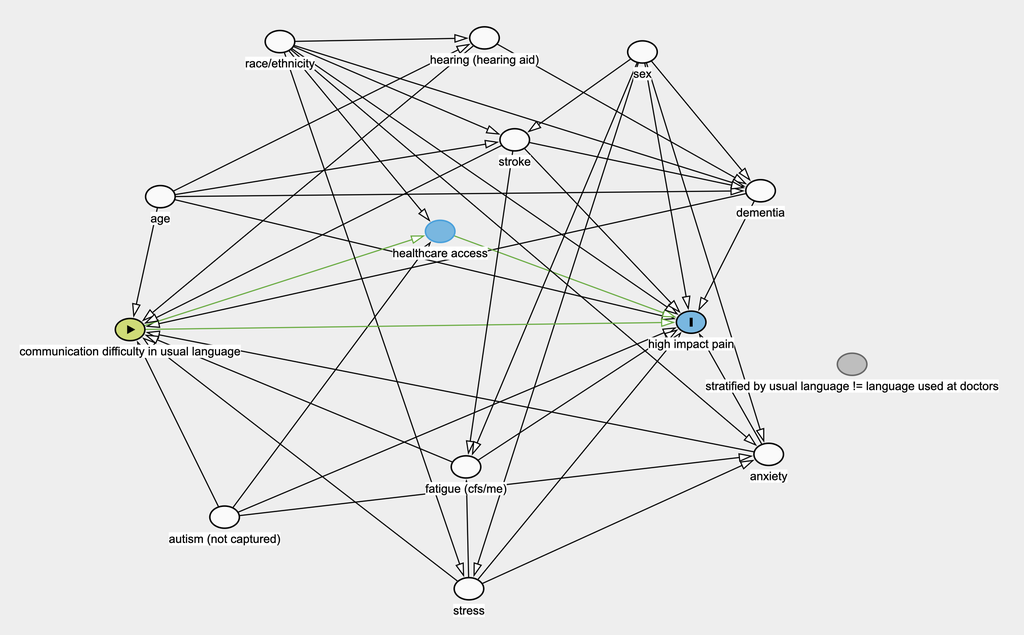

```r
knitr::include_graphics("dag_1122.png")
```

Because the communication variable asked about communication in one’s usual language, I decided to explore whether there was effect modification if one’s primary language differed with the language they used at the doctor’s. Participants were asked, first, whether they spoke a language other than English at home. If they responded yes, they were asked follow-up questions on what language they used when consuming media (watching television, reading news, or listening to the radio), seeing a doctor or other health care professional, and participating in social activities (visiting friends, clubs and meetings, going to parties). Participants could answer “English,” “Other language” or refuse/report unknown. If participants answered “Other language” for any of the follow-up questions, they were classified as having a non-English primary language. If a participant had a non-English primary language and reported using English with their healthcare provider, they were classified as a “no match”. If they had a non-English primary language and reported using their other language with their healthcare provider, they were classified as a “match”. Participants who reported no second language were automatically classified as a “match.” Participants were stratified by language “match” and “no match” to explore potential effect modification.

Due to a high level of missingness (~30%) in language variables, I decided to stratify by primary language in a subgroup analysis instead of the entire analytic population.

> Finalize data set before weighting

```r
## rename variables of interest (confounders, effect modifiers)
## isolate variables i want to work with
data <- data %>%
  rename(lang_other = LANGHM_A,
         lang_tv = LANGMED_A,
         lang_doc = LANGDOC_A,
         lang_soc = LANGSOC_A,
         race = HISPALLP_A,
         age = AGEP_A,
         hearing = HEARAID_A,
         dementia = DEMENEV_A,
         fatigue = CFSEV_A,
         anxiety = ANXEV_A,
         sex = SEX_A,
         stroke = STREV_A) %>%
  select(id,strata,sweight,psu,comdiff,pain,hip,hip_binary,
         lang_other,lang_tv,lang_doc,lang_soc,race,age,
         hearing,dementia,fatigue,anxiety,sex,stroke)

summary(data)
```

```
      id                strata         sweight           psu
 Length:29522       Min.   :100.0   Min.   : 1792   Min.   :  1.00
 Class :character   1st Qu.:111.0   1st Qu.: 4644   1st Qu.:  8.00
 Mode  :character   Median :126.0   Median : 7375   Median : 24.00
                    Mean   :125.5   Mean   : 8747   Mean   : 31.38
                    3rd Qu.:140.0   3rd Qu.:10995   3rd Qu.: 48.00
                    Max.   :151.0   Max.   :39926   Max.   :153.00

               comdiff           pain            hip          hip_binary
 None              :27796   Min.   :1.000   Min.   :1.000   Min.   :0.0000
 Some              : 1471   1st Qu.:1.000   1st Qu.:1.000   1st Qu.:0.0000
 Lots or Completely:  248   Median :2.000   Median :1.000   Median :0.0000
 NA's              :    7   Mean   :2.315   Mean   :1.533   Mean   :0.1085
                            3rd Qu.:3.000   3rd Qu.:2.000   3rd Qu.:0.0000
                            Max.   :9.000   Max.   :4.000   Max.   :1.0000
                                            NA's   :937     NA's   :937
   lang_other       lang_tv         lang_doc        lang_soc
 Min.   :1.000   Min.   :1.000   Min.   :1.000   Min.   :1.000
 1st Qu.:2.000   1st Qu.:1.000   1st Qu.:1.000   1st Qu.:1.000
 Median :2.000   Median :1.000   Median :1.000   Median :1.000
 Mean   :2.064   Mean   :1.393   Mean   :1.301   Mean   :1.481
 3rd Qu.:2.000   3rd Qu.:2.000   3rd Qu.:2.000   3rd Qu.:2.000
 Max.   :9.000   Max.   :9.000   Max.   :9.000   Max.   :9.000
 NA's   :7418    NA's   :25473   NA's   :25473   NA's   :25549
      race            age           hearing         dementia
 Min.   :1.000   Min.   :18.00   Min.   :1.000   Min.   :1.000
 1st Qu.:2.000   1st Qu.:37.00   1st Qu.:2.000   1st Qu.:2.000
 Median :2.000   Median :55.00   Median :2.000   Median :2.000
 Mean   :2.175   Mean   :53.27   Mean   :1.942   Mean   :1.992
 3rd Qu.:2.000   3rd Qu.:69.00   3rd Qu.:2.000   3rd Qu.:2.000
 Max.   :7.000   Max.   :99.00   Max.   :7.000   Max.   :9.000

    fatigue         anxiety           sex            stroke
 Min.   :1.000   Min.   :1.000   Min.   :1.000   Min.   :1.000
 1st Qu.:2.000   1st Qu.:2.000   1st Qu.:1.000   1st Qu.:2.000
 Median :2.000   Median :2.000   Median :2.000   Median :2.000
 Mean   :1.992   Mean   :1.827   Mean   :1.545   Mean   :1.969
 3rd Qu.:2.000   3rd Qu.:2.000   3rd Qu.:2.000   3rd Qu.:2.000
 Max.   :9.000   Max.   :9.000   Max.   :9.000   Max.   :9.000
```

```r
## check how many individuals i lose with complete case
## 932 (3% of total sample) missing outcome
dim(subset(data, complete.cases(comdiff,hip_binary,sex,
                                race,age,hearing,dementia,
                                fatigue,anxiety,stroke)))
```

```
[1] 28583    20
```

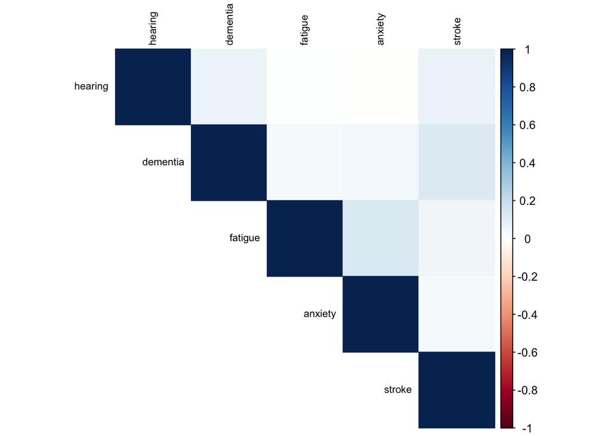

```r
## make na values na
cols <- c(6,9:12,15:20)
data <- data %>%
  mutate(across(all_of(cols), ~ if_else(.x >= 7, NA_real_, .x))) %>%
  mutate(age = ifelse(age > 85, NA, age))

## check for correlation between conditions
vars <- data[, c(15:18,20)]
vars01 <- as_tibble(ifelse(vars == 2, 1, 0))
cor_mat <- cor(vars01,use = "pairwise.complete.obs")
corrplot(cor_mat, method = "color",
         type = "upper", tl.col = "black", tl.cex = 0.7)
```

```r
## convert pain var to factors
data[,6:7] <- lapply(data[,6:7], factor,
                       levels = c(1:4),
                       labels = c("Never", "Some", "Most", "Every"))

## identify those reporting any other language as primary
data <- data %>%
  mutate(across(lang_tv:lang_soc, ~ as.factor(case_when(.x == 1 ~ "English",
                                              is.na(.x) ~ "Missing",
                                              .x == 2 ~ "Other language"))),
         primary_other = as.factor(ifelse(if_any(lang_tv:lang_soc, ~ .x == "Other language"),"Yes",NA)))
primary <- data %>%
  filter(is.na(primary_other)) %>%
  mutate(primary_English  = as.factor(ifelse(if_any(lang_tv:lang_soc, ~ .x == "English"),"No",NA)))
data <- data %>%
  mutate(primary_other = factor(primary_other,
                                levels = c("No","Yes")),
         primary_other = as.factor(ifelse(data$id %in% subset(primary,primary_English == "No")$id, 2, data$primary_other)))

## convert language vars to factors
data[data == "Missing"] <- NA
data[,10:12] <- lapply(data[,10:12], droplevels)

## convert y/n vars to factors
data[,c(9,15:18,20:21)] <- lapply(data[,c(9,15:18,20:21)], factor,
                       levels = c(1,2),
                       labels = c("Yes", "No"))

## make "no" the ref groups in y/n vars
data[,c(9,15:18,20:21)] <- lapply(data[,c(9,15:18,20:21)], relevel,
                            ref = "No")

## convert remaining vars to factors
data <- data %>%
  mutate(id = factor(id),
         hip_binary = factor(hip_binary,
                             levels = c(0,1),
                             labels = c("No","Yes")),
         race = factor(race,
                       levels = c(1:7),
                       labels = c("Hispanic","NH White","NH Black",
                                  "NH Asian", "NH AIAN only", "NH AIAN and other",
                                  "Other/Multi")),
         sex = factor(sex,
                      levels = c(1,2),
                      labels = c("Male","Female")))

## create variable for whether otherlang matches with lang_doc
## if don't speak second language other than English (lang_other),
### assume primary language matches with language used at doctors
data <- data %>%
  mutate(lang_match = as.factor(case_when(lang_other == "No" ~ "Match",
                                          lang_doc == "English" & primary_other == "No" ~ "Match",
                                          lang_doc == "Other language" & primary_other == "Yes" ~ "Match",
                                          lang_doc == "English" & primary_other == "Yes" ~ "No match",
                                          lang_doc == "Other language" & primary_other == "No" ~ "No match",
                                          TRUE ~ NA)))

summary(data)
```

```
       id            strata         sweight           psu
 H000002:    1   Min.   :100.0   Min.   : 1792   Min.   :  1.00
 H000005:    1   1st Qu.:111.0   1st Qu.: 4644   1st Qu.:  8.00
 H000006:    1   Median :126.0   Median : 7375   Median : 24.00
 H000007:    1   Mean   :125.5   Mean   : 8747   Mean   : 31.38
 H000008:    1   3rd Qu.:140.0   3rd Qu.:10995   3rd Qu.: 48.00
 H000011:    1   Max.   :151.0   Max.   :39926   Max.   :153.00
 (Other):29516
               comdiff         pain          hip        hip_binary
 None              :27796   Never: 8752   Never:18073   No  :25485
 Some              : 1471   Some :12111   Some : 7412   Yes : 3100
 Lots or Completely:  248   Most : 2945   Most : 1479   NA's:  937
 NA's              :    7   Every: 4791   Every: 1621
                            NA's :  923   NA's :  937


 lang_other             lang_tv                lang_doc
 No  :17145   English       : 2619   English       : 2928
 Yes : 4049   Other language: 1405   Other language: 1106
 NA's: 8328   NA's          :25498   NA's          :25488




           lang_soc                    race            age        hearing
 English       : 2255   Hispanic         : 4418   Min.   :18.00   No  :27784
 Other language: 1689   NH White         :19495   1st Qu.:37.00   Yes : 1734
 NA's          :25578   NH Black         : 3216   Median :55.00   NA's:    4
                        NH Asian         : 1668   Mean   :53.17
                        NH AIAN only     :  193   3rd Qu.:68.00
                        NH AIAN and other:  216   Max.   :85.00
                        Other/Multi      :  316   NA's   :65
 dementia     fatigue      anxiety          sex         stroke
 No  :29126   No  :29002   No  :24035   Male  :13457   No  :28351
 Yes :  371   Yes :  481   Yes : 5431   Female:16059   Yes : 1133
 NA's:   25   NA's:   39   NA's:   56   NA's  :    6   NA's:   38




 primary_other    lang_match
 No  : 2095    Match   :20345
 Yes : 1949    No match:  834
 NA's:25478    NA's    : 8343
```

```r
## save data as r data file for future easy loading
# save(data, file = "data.Rda")
# load("data.Rda")
```

Participants missing the exposure, outcome, or both variables were excluded from the calculation of the estimates. This resulted in a loss of approximately 3% of participants. The R package survey 4.4-8 allows for these excluded participants to stay included for the calculation of the standard errors. With the survey package, the data set was weighted according to the weights provided by the NHIS data set.

I conducted a logistic regression of communication difficulty on high impact pain, adjusted for sex, race/ethnicity, age (continuous), hearing loss, dementia, fatigue, anxiety, and stroke. All confounders were included as factors, unless otherwise specified.

> Apply weighting and logistic regression

```r
## apply weighting
weighted_data <- svydesign(id=~psu, weights=~sweight,
                          strata=~strata, nest=TRUE,
                          data = data)

## check number of individuals represented
sum(weights(weighted_data))
```

```
[1] 258237552
```

```r
## create subset of complete cases
weighted_sub <- subset(weighted_data, complete.cases(comdiff,hip_binary,sex,
                                                     race,age,hearing,dementia,
                                                     fatigue,anxiety,stroke))

## check to see that subsetting / weighting done correctly
svymean(~age,weighted_sub)
```

```
      mean     SE
age 48.046 0.1587
```

```r
svyby(~age,~I(complete.cases(comdiff,hip_binary,sex,
                                                     race,age,hearing,dementia,
                                                     fatigue,anxiety,stroke)),weighted_data,svymean)
```

```
      I(complete.cases(comdiff, hip_binary, sex, race, age, hearing, dementia, fatigue, anxiety, stroke))
FALSE                                                                                               FALSE
TRUE                                                                                                 TRUE
           age        se
FALSE       NA       NaN
TRUE  48.04612 0.1586884
```

```r
## check new number of individuals represented
sum(weights(weighted_sub))
```

```
[1] 248826036
```

```r
## fit univariate model
fit1_sub <- svyglm(hip_binary~comdiff,
                  family=quasibinomial,
                  design=weighted_sub, na.action = na.omit)

## fit demographic vars
fit2_sub <- svyglm(hip_binary~comdiff+sex+race+age,
                  family=quasibinomial,
                  design=weighted_sub, na.action = na.omit)

## fit all covariates
fit3_sub <- svyglm(hip_binary~comdiff+sex+race+age+hearing+dementia+fatigue+anxiety+stroke,
                  family=quasibinomial,
                  design=weighted_sub, na.action = na.omit)

## check results
summary(fit1_sub)
```

```
Call:
svyglm(formula = hip_binary ~ comdiff, design = weighted_sub,
    family = quasibinomial, na.action = na.omit)

Survey design:
subset(weighted_data, complete.cases(comdiff, hip_binary, sex,
    race, age, hearing, dementia, fatigue, anxiety, stroke))

Coefficients:
                          Estimate Std. Error t value Pr(>|t|)
(Intercept)               -2.35502    0.02609 -90.265  < 2e-16 ***
comdiffSome                1.19212    0.07604  15.677  < 2e-16 ***
comdiffLots or Completely  1.26346    0.15955   7.919 1.14e-14 ***
---
Signif. codes:  0 '***' 0.001 '**' 0.01 '*' 0.05 '.' 0.1 ' ' 1

(Dispersion parameter for quasibinomial family taken to be 1.000035)

Number of Fisher Scoring iterations: 5
```

```r
summary(fit2_sub)
```

```
Call:
svyglm(formula = hip_binary ~ comdiff + sex + race + age, design = weighted_sub,
    family = quasibinomial, na.action = na.omit)

Survey design:
subset(weighted_data, complete.cases(comdiff, hip_binary, sex,
    race, age, hearing, dementia, fatigue, anxiety, stroke))

Coefficients:
                          Estimate Std. Error t value Pr(>|t|)
(Intercept)               -3.82027    0.10308 -37.063  < 2e-16 ***
comdiffSome                1.10763    0.07971  13.895  < 2e-16 ***
comdiffLots or Completely  1.24206    0.16515   7.521 2.00e-13 ***
sexFemale                  0.26286    0.04553   5.773 1.25e-08 ***
raceNH White               0.10655    0.07382   1.443  0.14945
raceNH Black               0.11608    0.09456   1.228  0.22009
raceNH Asian              -0.95401    0.16076  -5.935 4.98e-09 ***
raceNH AIAN only           0.55115    0.26377   2.089  0.03708 *
raceNH AIAN and other      0.63557    0.22780   2.790  0.00544 **
raceOther/Multi           -0.19459    0.32069  -0.607  0.54422
age                        0.02474    0.00128  19.330  < 2e-16 ***
---
Signif. codes:  0 '***' 0.001 '**' 0.01 '*' 0.05 '.' 0.1 ' ' 1

(Dispersion parameter for quasibinomial family taken to be 0.9795374)

Number of Fisher Scoring iterations: 5
```

```r
summary(fit3_sub)
```

```
Call:
svyglm(formula = hip_binary ~ comdiff + sex + race + age + hearing +
    dementia + fatigue + anxiety + stroke, design = weighted_sub,
    family = quasibinomial, na.action = na.omit)

Survey design:
subset(weighted_data, complete.cases(comdiff, hip_binary, sex,
    race, age, hearing, dementia, fatigue, anxiety, stroke))

Coefficients:
                           Estimate Std. Error t value Pr(>|t|)
(Intercept)               -4.179493   0.110589 -37.793  < 2e-16 ***
comdiffSome                0.800727   0.085591   9.355  < 2e-16 ***
comdiffLots or Completely  0.946228   0.186121   5.084 4.96e-07 ***
sexFemale                  0.073581   0.047730   1.542   0.1237
raceNH White              -0.043702   0.074348  -0.588   0.5569
raceNH Black               0.108261   0.095031   1.139   0.2551
raceNH Asian              -0.824741   0.160940  -5.125 4.04e-07 ***
raceNH AIAN only           0.488582   0.267646   1.825   0.0684 .
raceNH AIAN and other      0.330579   0.253393   1.305   0.1925
raceOther/Multi           -0.226597   0.323616  -0.700   0.4841
age                        0.028638   0.001427  20.063  < 2e-16 ***
hearingYes                -0.107249   0.089416  -1.199   0.2308
dementiaYes               -0.135811   0.175086  -0.776   0.4382
fatigueYes                 1.679029   0.120095  13.981  < 2e-16 ***
anxietyYes                 1.160080   0.055170  21.027  < 2e-16 ***
strokeYes                  0.769335   0.092287   8.336 5.33e-16 ***
---
Signif. codes:  0 '***' 0.001 '**' 0.01 '*' 0.05 '.' 0.1 ' ' 1

(Dispersion parameter for quasibinomial family taken to be 0.9760873)

Number of Fisher Scoring iterations: 5
```

```r
## put in data frame
results_null <- rownames_to_column(as.data.frame(summary(fit1_sub)$coef),
                                   var = "Communication Difficulty Level") %>%
  mutate(or = round(exp(Estimate),digits = 2),
         lower.CI = round(exp(Estimate - 1.96*`Std. Error`),digits = 2),
         upper.CI = round(exp(Estimate + 1.96*`Std. Error`),digits = 2),
         `Pr(>|t|)` = signif(`Pr(>|t|)`, digits = 3),
         `Std. Error` = round(`Std. Error`, digits = 3)) %>%
  select(1,6,3,7:8,5)


## put in data frame
results_full <- rownames_to_column(as.data.frame(summary(fit3_sub)$coef),
                                   var = "Communication Difficulty Level") %>%
  mutate(or = exp(Estimate),
         lower.CI = exp(Estimate - 1.96*`Std. Error`),
         upper.CI = exp(Estimate + 1.96*`Std. Error`),
         `Pr(>|t|)` = signif(`Pr(>|t|)`, digits = 3),
         `Std. Error` = round(`Std. Error`, digits = 3)) %>%
  select(1,6,3,7:8,5)
```

As a subgroup analysis, I conducted the same logistic regression of communication difficulty on high impact pain, adjusted for sex, race/ethnicity, age (continuous), hearing loss, dementia, fatigue, anxiety, and stroke, but I restricted my analysis to those who had data on primary language language. Similar to the main analysis, I used a complete cases only.

> Apply subsetting + regression for subgroup analysis

```r
## create subset of complete cases, including lang_match as new covariate
weighted_sub2 <- subset(weighted_data, complete.cases(comdiff,hip_binary,sex,
                                                     race,age,hearing,dementia,
                                                     fatigue,anxiety,stroke,lang_match))

## check new number of individuals represented
sum(weights(weighted_sub2))
```

```
[1] 184316475
```

```r
## check number of individuals in actual dataset
dim(subset(data, complete.cases(comdiff,hip_binary,sex,
                                race,age,hearing,dementia,
                                fatigue,anxiety,stroke,lang_match)))
```

```
[1] 21053    22
```

```r
##further subset datasets into strata by lang_match
weighted_sub_match <- subset(weighted_sub2, lang_match == "Match")
weighted_sub_nomatch <- subset(weighted_sub2, lang_match == "No match")

## check number of individuals represented by each strata
sum(weights(weighted_sub_match))
```

```
[1] 175862331
```

```r
sum(weights(weighted_sub_nomatch))
```

```
[1] 8454144
```

```r
## check number of individuals in actual strata
dim(subset(subset(data, complete.cases(comdiff,hip_binary,sex,
                                race,age,hearing,dementia,
                                fatigue,anxiety,stroke,lang_match)),lang_match == "Match"))
```

```
[1] 20222    22
```

```r
dim(subset(subset(data, complete.cases(comdiff,hip_binary,sex,
                                race,age,hearing,dementia,
                                fatigue,anxiety,stroke,lang_match)),lang_match == "No match"))
```

```
[1] 831  22
```

```r
## check to see that subsetting / weighting done correctly
svymean(~age,weighted_sub_match)
```

```
      mean     SE
age 48.276 0.1801
```

```r
svyby(~age,~I(lang_match == "Match"),weighted_sub2,svymean)
```

```
      I(lang_match == "Match")      age        se
FALSE                    FALSE 44.21574 0.6461011
TRUE                      TRUE 48.27641 0.1800611
```

```r
svymean(~age,weighted_sub_nomatch)
```

```
      mean     SE
age 44.216 0.6461
```

```r
svyby(~age,~I(lang_match == "No match"),weighted_sub2,svymean)
```

```
      I(lang_match == "No match")      age        se
FALSE                       FALSE 48.27641 0.1800611
TRUE                         TRUE 44.21574 0.6461011
```

```r
## fit univariate model
fit1_sub_match <- svyglm(hip_binary~comdiff,
                  family=quasibinomial,
                  design=weighted_sub_match, na.action = na.omit)
fit1_sub_nomatch <- svyglm(hip_binary~comdiff,
                  family=quasibinomial,
                  design=weighted_sub_nomatch, na.action = na.omit)

## fit full model
fit3_sub_match <- svyglm(hip_binary~comdiff+sex+race+age+hearing+dementia+fatigue+anxiety+stroke,
                         family=quasibinomial,
                         design=weighted_sub_match, na.action = na.omit)
fit3_sub_nomatch <- svyglm(hip_binary~comdiff+sex+race+age+hearing+dementia+fatigue+anxiety+stroke,
                         family=quasibinomial,
                         design=weighted_sub_nomatch, na.action = na.omit)

## check results
summary(fit1_sub_match)
```

```
Call:
svyglm(formula = hip_binary ~ comdiff, design = weighted_sub_match,
    family = quasibinomial, na.action = na.omit)

Survey design:
subset(weighted_sub2, lang_match == "Match")

Coefficients:
                          Estimate Std. Error t value Pr(>|t|)
(Intercept)               -2.34364    0.02946 -79.549  < 2e-16 ***
comdiffSome                1.22848    0.09138  13.443  < 2e-16 ***
comdiffLots or Completely  1.37502    0.18313   7.509 2.15e-13 ***
---
Signif. codes:  0 '***' 0.001 '**' 0.01 '*' 0.05 '.' 0.1 ' ' 1

(Dispersion parameter for quasibinomial family taken to be 1.000049)

Number of Fisher Scoring iterations: 5
```

```r
summary(fit1_sub_nomatch)
```

```
Call:
svyglm(formula = hip_binary ~ comdiff, design = weighted_sub_nomatch,
    family = quasibinomial, na.action = na.omit)

Survey design:
subset(weighted_sub2, lang_match == "No match")

Coefficients:
                          Estimate Std. Error t value Pr(>|t|)
(Intercept)                -2.4741     0.1624 -15.232   <2e-16 ***
comdiffSome                 0.3011     0.5493   0.548    0.584
comdiffLots or Completely   1.1964     0.9667   1.238    0.217
---
Signif. codes:  0 '***' 0.001 '**' 0.01 '*' 0.05 '.' 0.1 ' ' 1

(Dispersion parameter for quasibinomial family taken to be 1.001205)

Number of Fisher Scoring iterations: 5
```

```r
summary(fit3_sub_match)
```

```
Call:
svyglm(formula = hip_binary ~ comdiff + sex + race + age + hearing +
    dementia + fatigue + anxiety + stroke, design = weighted_sub_match,
    family = quasibinomial, na.action = na.omit)

Survey design:
subset(weighted_sub2, lang_match == "Match")

Coefficients:
                          Estimate Std. Error t value Pr(>|t|)
(Intercept)               -4.14202    0.13735 -30.157  < 2e-16 ***
comdiffSome                0.84046    0.10047   8.365 4.30e-16 ***
comdiffLots or Completely  1.04562    0.21396   4.887 1.32e-06 ***
sexFemale                  0.08891    0.05534   1.607   0.1087
raceNH White              -0.03004    0.09799  -0.307   0.7592
raceNH Black               0.15411    0.12115   1.272   0.2039
raceNH Asian              -0.88904    0.22406  -3.968 8.14e-05 ***
raceNH AIAN only           0.56146    0.30866   1.819   0.0694 .
raceNH AIAN and other      0.26111    0.32280   0.809   0.4189
raceOther/Multi           -0.03732    0.35890  -0.104   0.9172
age                        0.02716    0.00161  16.868  < 2e-16 ***
hearingYes                -0.07497    0.10187  -0.736   0.4620
dementiaYes               -0.16829    0.19435  -0.866   0.3869
fatigueYes                 1.83413    0.15729  11.661  < 2e-16 ***
anxietyYes                 1.18177    0.06258  18.885  < 2e-16 ***
strokeYes                  0.78020    0.10591   7.367 5.90e-13 ***
---
Signif. codes:  0 '***' 0.001 '**' 0.01 '*' 0.05 '.' 0.1 ' ' 1

(Dispersion parameter for quasibinomial family taken to be 0.9876302)

Number of Fisher Scoring iterations: 5
```

```r
summary(fit3_sub_nomatch)
```

```
Call:
svyglm(formula = hip_binary ~ comdiff + sex + race + age + hearing +
    dementia + fatigue + anxiety + stroke, design = weighted_sub_nomatch,
    family = quasibinomial, na.action = na.omit)

Survey design:
subset(weighted_sub2, lang_match == "No match")

Coefficients:
                            Estimate Std. Error t value Pr(>|t|)
(Intercept)                -3.492076   0.600586  -5.814 1.47e-08 ***
comdiffSome                 0.344572   0.617033   0.558 0.576937
comdiffLots or Completely   1.335556   0.976047   1.368 0.172162
sexFemale                  -0.807378   0.333512  -2.421 0.016038 *
raceNH White               -1.191699   0.556322  -2.142 0.032935 *
raceNH Black               -0.235094   0.711085  -0.331 0.741152
raceNH Asian               -0.388479   0.388170  -1.001 0.317676
raceNH AIAN only           -0.664020   1.320706  -0.503 0.615465
raceOther/Multi           -14.345250   0.680256 -21.088  < 2e-16 ***
age                         0.026303   0.009973   2.637 0.008760 **
hearingYes                  0.713184   0.899548   0.793 0.428464
dementiaYes               -16.375136   1.409952 -11.614  < 2e-16 ***
fatigueYes                  3.335503   1.141644   2.922 0.003728 **
anxietyYes                  1.535093   0.399872   3.839 0.000149 ***
strokeYes                   1.878680   0.750168   2.504 0.012762 *
---
Signif. codes:  0 '***' 0.001 '**' 0.01 '*' 0.05 '.' 0.1 ' ' 1

(Dispersion parameter for quasibinomial family taken to be 1.007642)

Number of Fisher Scoring iterations: 15
```

```r
## put in data frame
results_match_null <- rownames_to_column(as.data.frame(summary(fit1_sub_match)$coef),
                                   var = "Communication Difficulty Level") %>%
  mutate(or = round(exp(Estimate),digits = 2),
         lower.CI = round(exp(Estimate - 1.96*`Std. Error`),digits = 2),
         upper.CI = round(exp(Estimate + 1.96*`Std. Error`),digits = 2),
         `Pr(>|t|)` = signif(`Pr(>|t|)`, digits = 3),
         `Std. Error` = round(`Std. Error`, digits = 3)) %>%
  select(1,6,3,7:8,5)

results_match_full <- rownames_to_column(as.data.frame(summary(fit3_sub_match)$coef),
                                   var = "Communication Difficulty Level") %>%
  mutate(or = round(exp(Estimate),digits = 2),
         lower.CI = round(exp(Estimate - 1.96*`Std. Error`),digits = 2),
         upper.CI = round(exp(Estimate + 1.96*`Std. Error`),digits = 2),
         `Pr(>|t|)` = signif(`Pr(>|t|)`, digits = 3),
         `Std. Error` = round(`Std. Error`, digits = 3)) %>%
  select(1,6,3,7:8,5)

results_nomatch_null <- rownames_to_column(as.data.frame(summary(fit1_sub_nomatch)$coef),
                                   var = "Communication Difficulty Level") %>%
  mutate(or = round(exp(Estimate),digits = 2),
         lower.CI = round(exp(Estimate - 1.96*`Std. Error`),digits = 2),
         upper.CI = round(exp(Estimate + 1.96*`Std. Error`),digits = 2),
         `Pr(>|t|)` = signif(`Pr(>|t|)`, digits = 3),
         `Std. Error` = round(`Std. Error`, digits = 3)) %>%
  select(1,6,3,7:8,5)

results_nomatch_full <- rownames_to_column(as.data.frame(summary(fit3_sub_nomatch)$coef),
                                   var = "Communication Difficulty Level") %>%
  mutate(or = round(exp(Estimate),digits = 2),
         lower.CI = round(exp(Estimate - 1.96*`Std. Error`),digits = 2),
         upper.CI = round(exp(Estimate + 1.96*`Std. Error`),digits = 2),
         `Pr(>|t|)` = signif(`Pr(>|t|)`, digits = 3),
         `Std. Error` = round(`Std. Error`, digits = 3)) %>%
  select(1,6,3,7:8,5)
```

## 4 Results

Describe your results and include relevant tables, plots, and code/comments used to obtain them. You may refer to the Section 3 as needed. End with a brief conclusion of your findings related to the question you set out to address. You can include references if you’d like, but this is not required.

### 4.1 Study Population

Table 1 shows selected characteristics of the U.S. adults examined in our analysis divided by communication difficulty. We examined N=28,444 respondents, representing a weighted N=248,826,036 individuals. Individuals with greater communication difficulty were more likely to be male, older and have ever diagnoses of dementia, anxiety, stroke, and hearing loss.

```r
table1_data <- subset(data, complete.cases(comdiff,hip_binary,sex,
                                race,age,hearing,dementia,
                                fatigue,anxiety,stroke))
## set var names
labels <- list(
    variables=list(sex="Sex",
                   age="Age (years)",
                   race = "Race and Ethnicity",
                   dementia="Dementia",
                   fatigue="Fatigue",
                   anxiety = "Anxiety",
                   stroke = "Stroke",
                   hearing = "Hearing loss"),
    groups=list("", "Communication Difficulty"))

## create strata for table
strata <- c(list(Total=table1_data), split(table1_data, table1_data$comdiff))

## generate table1
table1 <- table1(strata,labels,groupspan=c(1,3),
                 data=table1_data,overall=c(left="Total"),
                 caption="Table 1. Sample Characteristics")
table1
```

Table 1. Sample Characteristics

|  | Total (N=28444) | Communication Difficulty None (N=26812) | Communication Difficulty Some (N=1402) | Communication Difficulty Lots or Completely (N=230) |
| --- | --- | --- | --- | --- |
| Sex |  |  |  |  |
| Male | 13002 (45.7%) | 12223 (45.6%) | 655 (46.7%) | 124 (53.9%) |
| Female | 15442 (54.3%) | 14589 (54.4%) | 747 (53.3%) | 106 (46.1%) |
| Age (years) |  |  |  |  |
| Mean (SD) | 53.1 (18.5) | 52.8 (18.4) | 58.7 (20.1) | 58.5 (21.6) |
| Median [Min, Max] | 54.0 [18.0, 85.0] | 54.0 [18.0, 85.0] | 63.0 [18.0, 85.0] | 65.5 [19.0, 85.0] |
| Race and Ethnicity |  |  |  |  |
| Hispanic | 4249 (14.9%) | 3999 (14.9%) | 209 (14.9%) | 41 (17.8%) |
| NH White | 18905 (66.5%) | 17845 (66.6%) | 921 (65.7%) | 139 (60.4%) |
| NH Black | 3014 (10.6%) | 2815 (10.5%) | 165 (11.8%) | 34 (14.8%) |
| NH Asian | 1574 (5.5%) | 1498 (5.6%) | 64 (4.6%) | 12 (5.2%) |
| NH AIAN only | 188 (0.7%) | 169 (0.6%) | 18 (1.3%) | 1 (0.4%) |
| NH AIAN and other | 209 (0.7%) | 195 (0.7%) | 13 (0.9%) | 1 (0.4%) |
| Other/Multi | 305 (1.1%) | 291 (1.1%) | 12 (0.9%) | 2 (0.9%) |
| Dementia |  |  |  |  |
| No | 28091 (98.8%) | 26599 (99.2%) | 1314 (93.7%) | 178 (77.4%) |
| Yes | 353 (1.2%) | 213 (0.8%) | 88 (6.3%) | 52 (22.6%) |
| Fatigue |  |  |  |  |
| No | 27979 (98.4%) | 26428 (98.6%) | 1332 (95.0%) | 219 (95.2%) |
| Yes | 465 (1.6%) | 384 (1.4%) | 70 (5.0%) | 11 (4.8%) |
| Anxiety |  |  |  |  |
| No | 23180 (81.5%) | 22099 (82.4%) | 927 (66.1%) | 154 (67.0%) |
| Yes | 5264 (18.5%) | 4713 (17.6%) | 475 (33.9%) | 76 (33.0%) |
| Stroke |  |  |  |  |
| No | 27365 (96.2%) | 25930 (96.7%) | 1248 (89.0%) | 187 (81.3%) |
| Yes | 1079 (3.8%) | 882 (3.3%) | 154 (11.0%) | 43 (18.7%) |
| Hearing loss |  |  |  |  |
| No | 26757 (94.1%) | 25373 (94.6%) | 1198 (85.4%) | 186 (80.9%) |
| Yes | 1687 (5.9%) | 1439 (5.4%) | 204 (14.6%) | 44 (19.1%) |

### 4.2 Associations between communication difficulty and high impact pain

The association between communication difficulty level and high impact pain was statistically significant in U.S. adults before and after adjusting for covariates. Compared to those with no communication difficulty, adjusting for covariates, those with some communication difficulty had 2.23 times greater odds of high impact pain (95% CI, 1.88-2.63%; p<0.001), while those with lots of or complete communication difficulty had 2.58 times greater odds of high impact pain (95% CI, 1.79-3.71%; p<0.001) (Table 2).

```r
## main analysis output
results_null_gt <- tbl_regression(fit1_sub, exponentiate = T,
                                  label = list(comdiff = "Communication Difficulty Level"))

results_full_gt <- tbl_regression(fit3_sub, exponentiate = T,
                                  include = "comdiff",
                                  label = list(comdiff = "Communication Difficulty Level"))

## put into single table
table2 <-
  tbl_merge(
    tbls = list(results_null_gt, results_full_gt),
    tab_spanner = c("**Univariate Model**", "**Multivariate Model**")
  ) %>%
  modify_caption("**Table 2. Logistic Regression Results**")

table2
```

**Table 2. Logistic Regression Results**

| **Characteristic** | **Univariate Model** **OR** | **Univariate Model** **95% CI** | **Univariate Model** **p-value** | **Multivariate Model** **OR** | **Multivariate Model** **95% CI** | **Multivariate Model** **p-value** |
| --- | --- | --- | --- | --- | --- | --- |
| Communication Difficulty Level |  |  |  |  |  |  |
| None | — | — |  | — | — |  |
| Some | 3.29 | 2.84, 3.82 | <0.001 | 2.23 | 1.88, 2.63 | <0.001 |
| Lots or Completely | 3.54 | 2.59, 4.84 | <0.001 | 2.58 | 1.79, 3.71 | <0.001 |

Abbreviations: CI = Confidence Interval, OR = Odds Ratio

### 4.3 Subgroup Analysis

```r
table3_data_sub <- subset(data, complete.cases(comdiff,hip_binary,sex,
                                race,age,hearing,dementia,
                                fatigue,anxiety,stroke,lang_match))

## set var names
labels <- list(
    variables=list(sex="Sex",
                   age="Age (years)",
                   race = "Race and Ethnicity",
                   dementia="Dementia",
                   fatigue="Fatigue",
                   anxiety = "Anxiety",
                   stroke = "Stroke",
                   hearing = "Hearing loss"),
    groups=list("Total", "Match", "No Match"))

## create strata for table
strata <- c(list(Total=table3_data_sub),
            split(table3_data_sub, table3_data_sub$comdiff),
            list("Total"=subset(table3_data_sub, lang_match=="Match")),
            split(subset(table3_data_sub, lang_match=="Match"),
                  subset(table3_data_sub, lang_match=="Match")$comdiff),
            list("Total"=subset(table3_data_sub, lang_match=="No match")),
            split(subset(table3_data_sub, lang_match=="No match"),
                  subset(table3_data_sub, lang_match=="No match")$comdiff))

## generate table1
table3 <- table1(strata,labels,groupspan=c(4,4,4),
                 data=table3_data_sub,overall=c(left="Total"),
                 caption="Table 3. Subgroup Sample Characteristics")
table3
```

Table 3. Subgroup Sample Characteristics

|  | Total Total (N=21053) | Total None (N=19845) | Total Some (N=1031) | Total Lots or Completely (N=177) | Match Total (N=20222) | Match None (N=19065) | Match Some (N=986) | Match Lots or Completely (N=171) | No Match Total (N=831) | No Match None (N=780) | No Match Some (N=45) | No Match Lots or Completely (N=6) |
| --- | --- | --- | --- | --- | --- | --- | --- | --- | --- | --- | --- | --- |
| Sex |  |  |  |  |  |  |  |  |  |  |  |  |
| Male | 9564 (45.4%) | 8990 (45.3%) | 481 (46.7%) | 93 (52.5%) | 9203 (45.5%) | 8650 (45.4%) | 462 (46.9%) | 91 (53.2%) | 361 (43.4%) | 340 (43.6%) | 19 (42.2%) | 2 (33.3%) |
| Female | 11489 (54.6%) | 10855 (54.7%) | 550 (53.3%) | 84 (47.5%) | 11019 (54.5%) | 10415 (54.6%) | 524 (53.1%) | 80 (46.8%) | 470 (56.6%) | 440 (56.4%) | 26 (57.8%) | 4 (66.7%) |
| Age (years) |  |  |  |  |  |  |  |  |  |  |  |  |
| Mean (SD) | 53.3 (18.6) | 53.0 (18.4) | 58.7 (20.3) | 59.4 (21.5) | 53.6 (18.6) | 53.3 (18.4) | 59.1 (20.3) | 59.3 (21.6) | 46.4 (16.7) | 46.1 (16.5) | 49.7 (18.4) | 62.3 (20.5) |
| Median [Min, Max] | 55.0 [18.0, 85.0] | 54.0 [18.0, 85.0] | 63.0 [18.0, 85.0] | 67.0 [19.0, 85.0] | 55.0 [18.0, 85.0] | 55.0 [18.0, 85.0] | 63.5 [18.0, 85.0] | 67.0 [19.0, 85.0] | 44.0 [18.0, 85.0] | 44.0 [18.0, 85.0] | 45.0 [19.0, 85.0] | 67.0 [33.0, 82.0] |
| Race and Ethnicity |  |  |  |  |  |  |  |  |  |  |  |  |
| Hispanic | 3118 (14.8%) | 2933 (14.8%) | 152 (14.7%) | 33 (18.6%) | 2662 (13.2%) | 2502 (13.1%) | 128 (13.0%) | 32 (18.7%) | 456 (54.9%) | 431 (55.3%) | 24 (53.3%) | 1 (16.7%) |
| NH White | 14105 (67.0%) | 13320 (67.1%) | 677 (65.7%) | 108 (61.0%) | 14001 (69.2%) | 13224 (69.4%) | 671 (68.1%) | 106 (62.0%) | 104 (12.5%) | 96 (12.3%) | 6 (13.3%) | 2 (33.3%) |
| NH Black | 2175 (10.3%) | 2026 (10.2%) | 126 (12.2%) | 23 (13.0%) | 2128 (10.5%) | 1983 (10.4%) | 122 (12.4%) | 23 (13.5%) | 47 (5.7%) | 43 (5.5%) | 4 (8.9%) | 0 (0%) |
| NH Asian | 1161 (5.5%) | 1100 (5.5%) | 50 (4.8%) | 11 (6.2%) | 952 (4.7%) | 902 (4.7%) | 42 (4.3%) | 8 (4.7%) | 209 (25.2%) | 198 (25.4%) | 8 (17.8%) | 3 (50.0%) |
| NH AIAN only | 129 (0.6%) | 117 (0.6%) | 11 (1.1%) | 1 (0.6%) | 117 (0.6%) | 108 (0.6%) | 8 (0.8%) | 1 (0.6%) | 12 (1.4%) | 9 (1.2%) | 3 (6.7%) | 0 (0%) |
| NH AIAN and other | 152 (0.7%) | 146 (0.7%) | 6 (0.6%) | 0 (0%) | 152 (0.8%) | 146 (0.8%) | 6 (0.6%) | 0 (0%) | 0 (0%) | 0 (0%) | 0 (0%) | 0 (0%) |
| Other/Multi | 213 (1.0%) | 203 (1.0%) | 9 (0.9%) | 1 (0.6%) | 210 (1.0%) | 200 (1.0%) | 9 (0.9%) | 1 (0.6%) | 3 (0.4%) | 3 (0.4%) | 0 (0%) | 0 (0%) |
| Dementia |  |  |  |  |  |  |  |  |  |  |  |  |
| No | 20773 (98.7%) | 19667 (99.1%) | 973 (94.4%) | 133 (75.1%) | 19947 (98.6%) | 18890 (99.1%) | 929 (94.2%) | 128 (74.9%) | 826 (99.4%) | 777 (99.6%) | 44 (97.8%) | 5 (83.3%) |
| Yes | 280 (1.3%) | 178 (0.9%) | 58 (5.6%) | 44 (24.9%) | 275 (1.4%) | 175 (0.9%) | 57 (5.8%) | 43 (25.1%) | 5 (0.6%) | 3 (0.4%) | 1 (2.2%) | 1 (16.7%) |
| Fatigue |  |  |  |  |  |  |  |  |  |  |  |  |
| No | 20722 (98.4%) | 19567 (98.6%) | 985 (95.5%) | 170 (96.0%) | 19900 (98.4%) | 18795 (98.6%) | 941 (95.4%) | 164 (95.9%) | 822 (98.9%) | 772 (99.0%) | 44 (97.8%) | 6 (100%) |
| Yes | 331 (1.6%) | 278 (1.4%) | 46 (4.5%) | 7 (4.0%) | 322 (1.6%) | 270 (1.4%) | 45 (4.6%) | 7 (4.1%) | 9 (1.1%) | 8 (1.0%) | 1 (2.2%) | 0 (0%) |
| Anxiety |  |  |  |  |  |  |  |  |  |  |  |  |
| No | 17131 (81.4%) | 16334 (82.3%) | 682 (66.1%) | 115 (65.0%) | 16377 (81.0%) | 15626 (82.0%) | 642 (65.1%) | 109 (63.7%) | 754 (90.7%) | 708 (90.8%) | 40 (88.9%) | 6 (100%) |
| Yes | 3922 (18.6%) | 3511 (17.7%) | 349 (33.9%) | 62 (35.0%) | 3845 (19.0%) | 3439 (18.0%) | 344 (34.9%) | 62 (36.3%) | 77 (9.3%) | 72 (9.2%) | 5 (11.1%) | 0 (0%) |
| Stroke |  |  |  |  |  |  |  |  |  |  |  |  |
| No | 20235 (96.1%) | 19169 (96.6%) | 921 (89.3%) | 145 (81.9%) | 19417 (96.0%) | 18399 (96.5%) | 877 (88.9%) | 141 (82.5%) | 818 (98.4%) | 770 (98.7%) | 44 (97.8%) | 4 (66.7%) |
| Yes | 818 (3.9%) | 676 (3.4%) | 110 (10.7%) | 32 (18.1%) | 805 (4.0%) | 666 (3.5%) | 109 (11.1%) | 30 (17.5%) | 13 (1.6%) | 10 (1.3%) | 1 (2.2%) | 2 (33.3%) |
| Hearing loss |  |  |  |  |  |  |  |  |  |  |  |  |
| No | 19780 (94.0%) | 18765 (94.6%) | 873 (84.7%) | 142 (80.2%) | 18963 (93.8%) | 17998 (94.4%) | 828 (84.0%) | 137 (80.1%) | 817 (98.3%) | 767 (98.3%) | 45 (100%) | 5 (83.3%) |
| Yes | 1273 (6.0%) | 1080 (5.4%) | 158 (15.3%) | 35 (19.8%) | 1259 (6.2%) | 1067 (5.6%) | 158 (16.0%) | 34 (19.9%) | 14 (1.7%) | 13 (1.7%) | 0 (0%) | 1 (16.7%) |

In the language matrch statum, compared to those with no communication difficulty, adjusting for covariates, those with some communication difficulty had 2.32 times greater odds of high impact pain (95% CI, 1.90-2.82%; p<0.001), while those with lots of or complete communication difficulty had 2.85 times greater odds of high impact pain (95% CI, 1.87-4.33%; p<0.001) (Table 4a). These results are similar to that in the full analytic sample.

```r
## subgroup analysis output
## match tables
results_match_null_gt <- tbl_regression(fit1_sub_match, exponentiate = T,
                                  label = list(comdiff = "Communication Difficulty Level"),
                                  pvalue_fun = label_style_pvalue(digits = 3))
results_match_full_gt <- tbl_regression(fit3_sub_match, exponentiate = T,
                                  include = "comdiff",
                                  label = list(comdiff = "Communication Difficulty Level"),
                                  pvalue_fun = label_style_pvalue(digits = 3))
table4a <-
  tbl_merge(
    tbls = list(results_match_null_gt, results_match_full_gt),
    tab_spanner = c("**Univariate Model**", "**Multivariate Model**")
  ) %>%
  modify_caption("**Table 4a. Language Match Regression Results**")
table4a
```

**Table 4a. Language Match Regression Results**

| **Characteristic** | **Univariate Model** **OR** | **Univariate Model** **95% CI** | **Univariate Model** **p-value** | **Multivariate Model** **OR** | **Multivariate Model** **95% CI** | **Multivariate Model** **p-value** |
| --- | --- | --- | --- | --- | --- | --- |
| Communication Difficulty Level |  |  |  |  |  |  |
| None | — | — |  | — | — |  |
| Some | 3.42 | 2.85, 4.09 | <0.001 | 2.32 | 1.90, 2.82 | <0.001 |
| Lots or Completely | 3.96 | 2.76, 5.67 | <0.001 | 2.85 | 1.87, 4.33 | <0.001 |

Abbreviations: CI = Confidence Interval, OR = Odds Ratio

```r
## no match tables
results_nomatch_null_gt <- tbl_regression(fit1_sub_nomatch, exponentiate = T,
                                  label = list(comdiff = "Communication Difficulty Level"),
                                  pvalue_fun = label_style_pvalue(digits = 3))
results_nomatch_full_gt <- tbl_regression(fit3_sub_nomatch, exponentiate = T,
                                  include = "comdiff",
                                  label = list(comdiff = "Communication Difficulty Level"),
                                  pvalue_fun = label_style_pvalue(digits = 3))

table4b <-
  tbl_merge(
    tbls = list(results_nomatch_null_gt, results_nomatch_full_gt),
    tab_spanner = c("**Univariate Model**", "**Multivariate Model**")
  ) %>%
  modify_caption("**Table 4b. Language No-Match Regression Results**")
table4b
```

**Table 4b. Language No-Match Regression Results**

| **Characteristic** | **Univariate Model** **OR** | **Univariate Model** **95% CI** | **Univariate Model** **p-value** | **Multivariate Model** **OR** | **Multivariate Model** **95% CI** | **Multivariate Model** **p-value** |
| --- | --- | --- | --- | --- | --- | --- |
| Communication Difficulty Level |  |  |  |  |  |  |
| None | — | — |  | — | — |  |
| Some | 1.35 | 0.46, 3.98 | 0.584 | 1.41 | 0.42, 4.75 | 0.577 |
| Lots or Completely | 3.31 | 0.49, 22.2 | 0.217 | 3.80 | 0.56, 25.9 | 0.172 |

Abbreviations: CI = Confidence Interval, OR = Odds Ratio